# Volvo sales

Let’s plot the time series of sales of Volvo. The sales are of Norway.

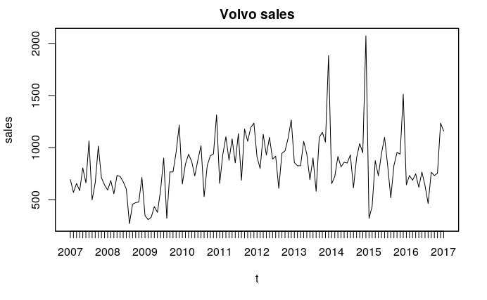

```r
suppressMessages(library(zoo))
suppressMessages(library(forecast))
df = read.csv('datasets_830_1554_norway_new_car_sales_by_make.csv')
df = subset(df, Make == 'Volvo')
sales = zooreg(data = df$Quantity, as.yearmon("2007-01-01"), freq = 12)
N = length(sales)
t = c(1:N)
Q = factor(c(rep(c(1:12), N/12), c(1:(N%%12))))
plot(sales, main = "Volvo sales", xlab = "t")
```

The rest of our work will consist in fitting some models in a window of two years and trying to predict the next month. The plots will show the original and the predicted time series.

## Regression

It seems reasonable to have seasonality of 12 months, so we will use it.

### Seasonal dummies

We will now fit a regression model that consist of trend and seasonality coefficients, using seasonal summies too. Note how we apply the two years window.

```r
next_step = function(t) {
  train = data.frame(
    t = t[1:24],
    sales = sales[t[1:24]],
    Q = Q[t[1:24]]
  )
  mod = lm(sales~t+Q, data = train)
  prediction = predict(mod, data.frame(t=t[25], Q=Q[t[25]]))
  return(prediction)
}
prediction = rollapply(t, 25, next_step)
plot(sales, main = "Seasonal dummies prediction", xlab = "t")
lines(time(sales)[25:length(t)], prediction, col = "red")
```

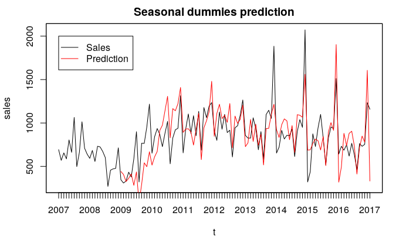

```r
legend(
  x = time(sales)[1],
  y = 2000,
  legend = c('Sales', 'Prediction'),
  col = c('black', 'red'),
  pch = c('', ''),
  lty = c(1, 1)
)
```

```r
mape = mean(abs((prediction - sales[25:length(sales)])/sales[25:length(sales)]))
paste("MAPE =", mape)
```

```
[1] "MAPE = 0,214958623085887"
```

We see a reasonable MAPE and plot.

### Polynomial

Now we add a two degree polynomial to the last model.

```r
library(zoo)
next_step = function(t) {
  train = data.frame(
    t = t[1:24],
    sales = sales[t[1:24]],
    Q = Q[t[1:24]]
  )
  mod = lm(sales~poly(t, 2)+Q, data = train)
  prediction = predict(mod, data.frame(t=t[25], Q=Q[t[25]]))
  return(prediction)
}
prediction = rollapply(t, 25, next_step)
plot(sales, main = "Polynomial 2nd order and seasonal dummies prediction", xlab = "t")
lines(time(sales)[25:length(t)], prediction, col = "red")
```

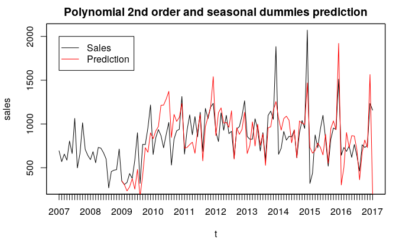

```r
legend(
  x = time(sales)[1],
  y = 2000,
  legend = c('Sales', 'Prediction'),
  col = c('black', 'red'),
  pch = c('', ''),
  lty = c(1, 1)
)
```

```r
mape = mean(abs((prediction - sales[25:length(sales)])/sales[25:length(sales)]))
paste("MAPE =", mape)
```

```
[1] "MAPE = 0,213598454013614"
```

The results are close to the last one.

## Decomposition

We will now use a function to decompose our series.

```r
next_step = function(t) {
  mod = stl(sales[t[1:25]], s.window = "periodic")
  prediction = forecast(mod, h=1)
  return(as.numeric(prediction$mean))
}
prediction = rollapply(t, 26, next_step)
plot(sales, main = "Decomposition prediction", xlab = "t")
lines(time(sales)[26:length(t)], prediction, col = "red")
```

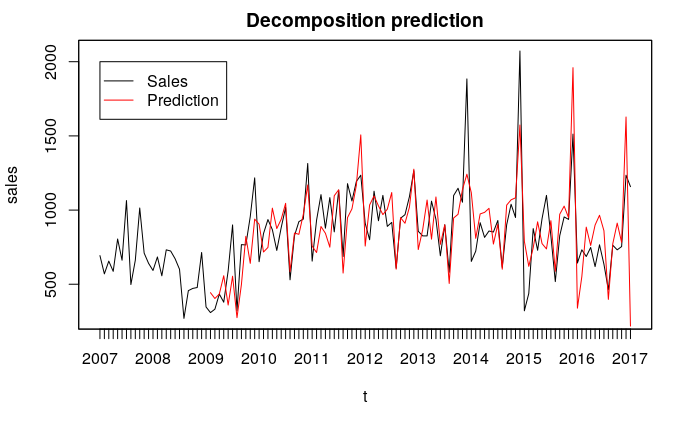

```r
legend(
  x = time(sales)[1],
  y = 2000,
  legend = c('Sales', 'Prediction'),
  col = c('black', 'red'),
  pch = c('', ''),
  lty = c(1, 1)
)
```

```r
mape = mean(abs((prediction - sales[26:length(sales)])/sales[26:length(sales)]))
paste("MAPE =", mape)
```

```
[1] "MAPE = 0,195302561502996"
```

Interesting results.

## Exponential smoothing

Now we will fit some models based on exponential smoothing.

### Exponential smoothing

This is the basic exponential smoothing model. It only considerates constant mean.

```r
next_step = function(t) {
  train = data.frame(
    t = t[1:24],
    sales = sales[t[1:24]],
    Q = Q[t[1:24]]
  )
  mod = HoltWinters(train$sales, beta = F, gamma = F)
  prediction = forecast(mod, 1)
  return(prediction$mean)
}
prediction = rollapply(t, 25, next_step)
plot(sales, main = "Exponential smoothing prediction", xlab = "t")
lines(time(sales)[25:length(t)], prediction, col = "red")
```

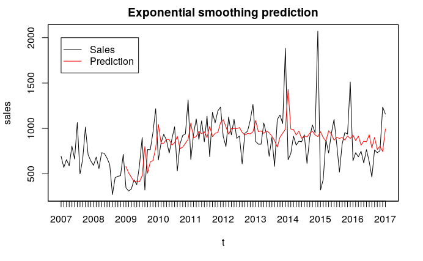

```r
legend(
  x = time(sales)[1],
  y = 2000,
  legend = c('Sales', 'Prediction'),
  col = c('black', 'red'),
  pch = c('', ''),
  lty = c(1, 1)
)
```

```r
mape = mean(abs((prediction - sales[25:length(sales)])/sales[25:length(sales)]))
paste("MAPE =", mape)
```

```
[1] "MAPE = 0,277045393426693"
```

The MAPE is worse than before.

### Holt

Now we have trend in our model.

```r
next_step = function(t) {
  train = data.frame(
    t = t[1:24],
    sales = sales[t[1:24]],
    Q = Q[t[1:24]]
  )
  mod = HoltWinters(train$sales, beta = T, gamma = F)
  prediction = forecast(mod, 1)
  return(prediction$mean)
}
prediction = rollapply(t, 25, next_step)
plot(sales, main = "Holt prediction", xlab = "t")
lines(time(sales)[25:length(t)], prediction, col = "red")
```

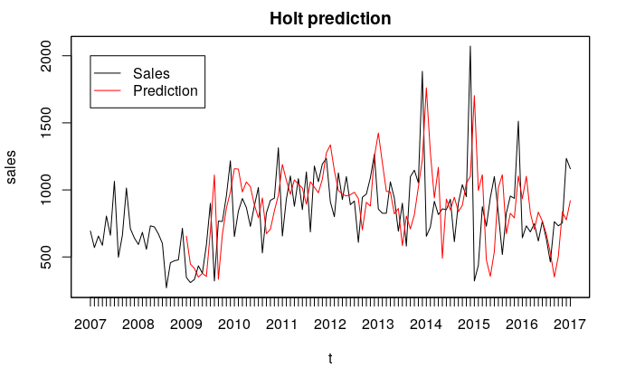

```r
legend(
  x = time(sales)[1],
  y = 2000,
  legend = c('Sales', 'Prediction'),
  col = c('black', 'red'),
  pch = c('', ''),
  lty = c(1, 1)
)
```

```r
mape = mean(abs((prediction - sales[25:length(sales)])/sales[25:length(sales)]))
paste("MAPE =", mape)
```

```
[1] "MAPE = 0,367475797650731"
```

It’s even worse.

### Additive Holt-Winters

We will now consider the complete Holt-Winters, with seasonality. This time it’s additive.

```r
next_step = function(t) {
  train = data.frame(
    t = t[1:24],
    sales = sales[t[1:24]],
    Q = Q[t[1:24]]
  )
  mod = HoltWinters(ts(train$sales, frequency = 12), beta = T, gamma = T, seasonal = "additive")
  prediction = forecast(mod, 1)
  return(prediction$mean)
}
prediction = rollapply(t, 25, next_step)
plot(sales, main = "Additive Holt-Winters prediction", xlab = "t")
lines(time(sales)[25:length(t)], prediction, col = "red")
```

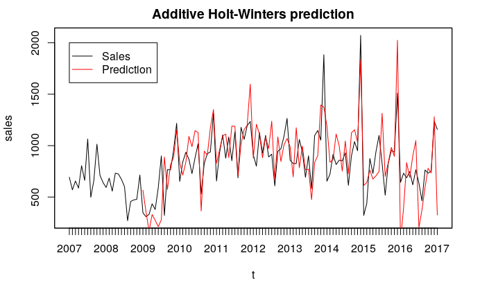

```r
legend(
  x = time(sales)[1],
  y = 2000,
  legend = c('Sales', 'Prediction'),
  col = c('black', 'red'),
  pch = c('', ''),
  lty = c(1, 1)
)
```

```r
mape = mean(abs((prediction - sales[25:length(sales)])/sales[25:length(sales)]))
paste("MAPE =", mape)
```

```
[1] "MAPE = 0,247905784030637"
```

We see improvements.

### Multiplicative Holt-Winters

Now the model is multiplicative.

```r
next_step = function(t) {
  train = data.frame(
    t = t[1:24],
    sales = sales[t[1:24]],
    Q = Q[t[1:24]]
  )
  mod = HoltWinters(ts(train$sales, frequency = 12), beta = T, gamma = T, seasonal = "multiplicative")
  prediction = forecast(mod, 1)
  return(prediction$mean)
}
prediction = rollapply(t, 25, next_step)
plot(sales, main = "Seasonal Holt-Winters prediction", xlab = "t")
lines(time(sales)[25:length(t)], prediction, col = "red")
```

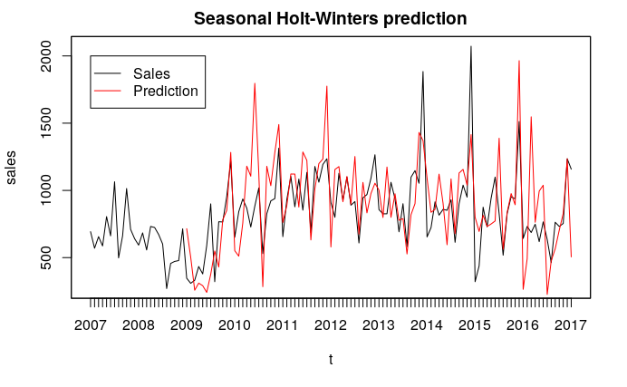

```r
legend(
  x = time(sales)[1],
  y = 2000,
  legend = c('Sales', 'Prediction'),
  col = c('black', 'red'),
  pch = c('', ''),
  lty = c(1, 1)
)
```

```r
mape = mean(abs((prediction - sales[25:length(sales)])/sales[25:length(sales)]))
paste("MAPE =", mape)
```

```
[1] "MAPE = 0,276258405722419"
```

It’s algo good.